# Week 7 - Milestone One week

# 1. Lesson: no lesson this week. Milestone One is due!

# 2. Weekly graph question

Below are the graphs from last week's weekly graph question. Suppose you wanted to cause the viewer to examine the last three months of data first. How could you use preattentive attributes to do that? Suggest several possibilities.

One attribute to use is leveraging color to draw attention. By using a color like blue for the last 3 months of the line, and grey for the rest, it will draw the users eyes to the period of analysis.

Another option is to add data labels to the plot for the last 3 months. This causes the same effect, the user will focus on the point of the plot which contains the data labels.

Size can also be leveraged. If we add data labels, we can increase the size of the labels to draw attention.

```python
import numpy as np
import seaborn as sns
import pandas as pd
```

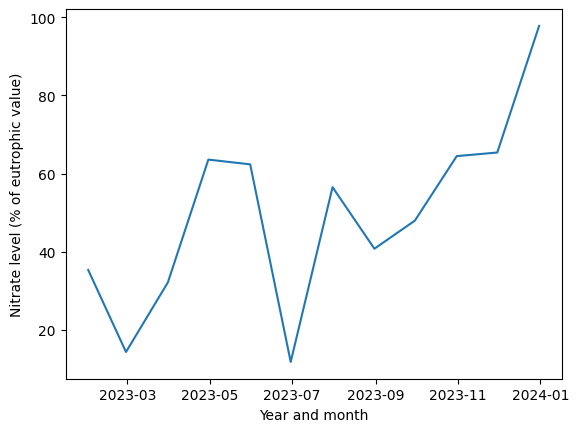

```python
numdates = 12
np.random.seed(0)
time_series = 100 * (np.random.normal(size = numdates) / 5 + np.arange(numdates) / 16)
datearray = pd.date_range(start='2023/01/01', end='2024/01/01', freq='M')
ax = sns.lineplot(x = datearray, y = time_series)
ax.set_xlabel("Year and month")
ax.set_ylabel("Nitrate level (% of eutrophic value)")
```

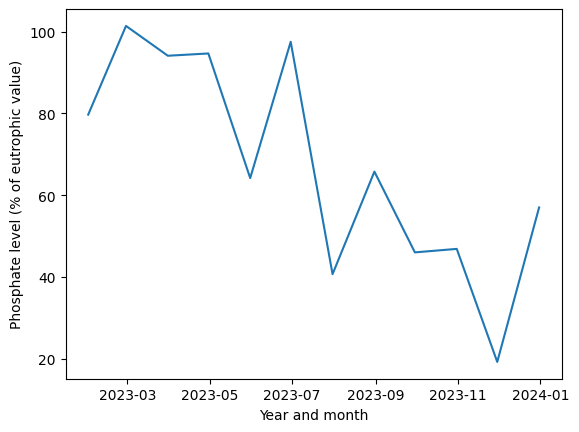

```python
np.random.seed(1)
time_series = 100 * (1 - (np.random.normal(size = numdates) / 8 + np.arange(numdates) / 16))
datearray = pd.date_range(start='2023/01/01', end='2024/01/01', freq='M')
ax = sns.lineplot(x = datearray, y = time_series)
ax.set_xlabel("Year and month")
ax.set_ylabel("Phosphate level (% of eutrophic value)")
```

# 3. Working on your datasets

This week, you can work on Milestone One rather than having a particular exercise about working on your datasets

# 4. Storytelling With Data plot

Reproduce any graph of your choice in p. 99-119 of the Storytelling With Data book as best you can. (The first half of chapter four). You do not have to get the exact data values right, just the overall look and feel.

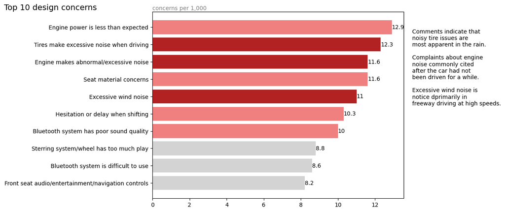

```python
# Figure 4.9 (p. 111)
import matplotlib.pyplot as plt

labels = [
    'Front seat audio/entertainment/navigation controls',
    'Bluetooth system is difficult to use',
    'Sterring system/wheel has too much play',
    'Bluetooth system has poor sound quality',
    'Hesitation or delay when shifting',
    'Excessive wind noise',
    'Seat material concerns',
    'Engine makes abnormal/excessive noise',
    'Tires make excessive noise when driving',
    'Engine power is less than expected'
]
y_pos = np.arange(len(labels))
data = [
    8.2, 8.6, 8.8, 10.0, 10.3, 11.0, 11.6, 11.6, 12.3, 12.9
]
colors = ['lightgray','lightgray','lightgray','lightcoral','lightcoral','firebrick','lightcoral','firebrick','firebrick','lightcoral']

plt.figure(figsize=(8, 6))
bars = plt.barh(y_pos, data, color=colors)
plt.bar_label(bars)
plt.yticks(
    y_pos,
    labels
)
plt.text(-8, 10.0, 'Top 10 design concerns', fontsize=14)
plt.text(0, 10.0, 'concerns per 1,000', fontsize=10, color='grey')
plt.text(14, 4.5, 'Comments indicate that \nnoisy tire issues are \nmost apparent in the rain. \n\nComplaints about engine \nnoise commonly cited \nafter the car had not \nbeen driven for a while. \n\nExcessive wind noise is \nnotice dprimarily in \nfreeway driving at high speeds.', fontsize=10)
None
```